# A3: SPL Library Checkouts

### Summary Information

For this assignment, I analyzed all PHYSICAL checkouts from the library through 2022. In my analysis I discovered that the most popular author of 2022 was Emily St. John Mandel, with the most popular book being of the year *Sea of Tranquility* written by her. I also learned, the most popular month for checking out books was January, most likely due to New Years resolutions towards reading. Lastly, I discovered that behind book checkouts, video and sound discs were the most commonly checked out material type.

### The Dataset

- Who collected/published the data?

The Seattle Public Library

- What are the parameters of the data (dates, number of checkouts, kinds of books, etc.)?

They refresh monthly, but keep track of way more than just book checkouts. They also collect data on items checked out online. It goes back to Apr2005

- How was the data collected or generated?

This data was collected using a monthly count of Seattle Public Library checkouts of both physical and electronic items

- Why was the data collected?

They claim to collect this data to: improve public understanding, generate economic opportunity, empower city employees, and encourage development.

- What, if any, ethical questions do you need to consider when working with this data?

I do not see any ethical concerns when it comes to this data; however, if this data starts to include PERSONAL information of those who checkout books, or if the data is used towards book banning or de-funding the library, then I think it starts to enter an unethical territory.

- What are possible limitations or problems with this data? (at least 200 words)

One that comes to mind is we don’t know who is checking out what. For instance, one individual may be using the library extremely frequently, checking out many more books than the average individual, which will make statistics on checkouts more skewed to their interests.

### First Trends Over Time Chart

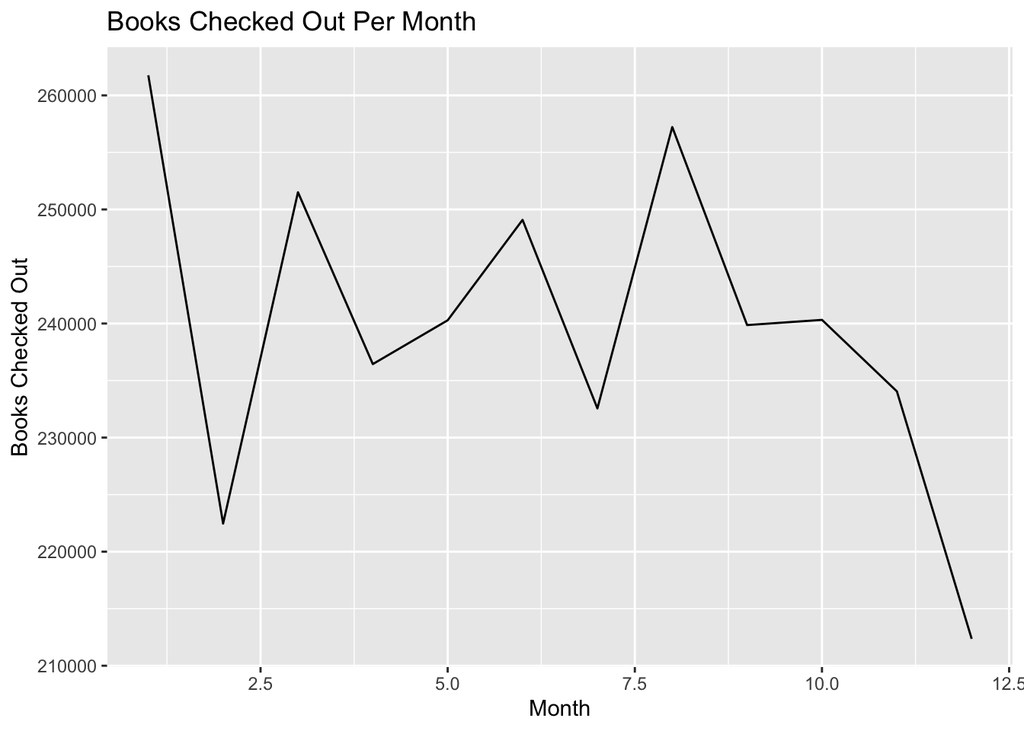

### Second Trends Over Time Chart

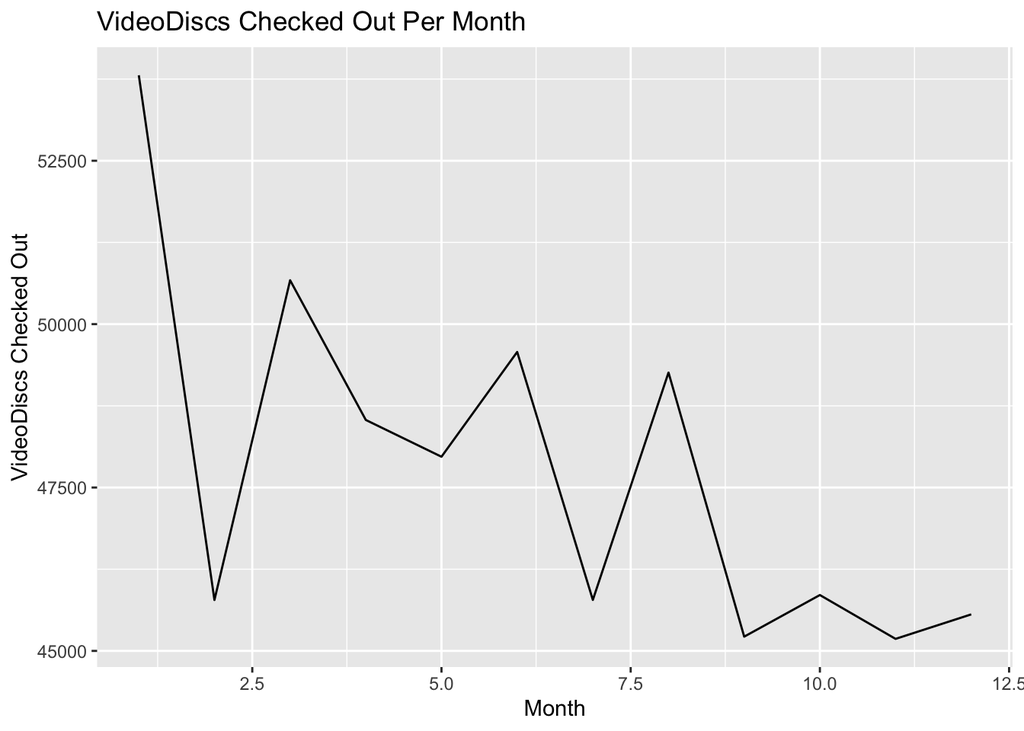

### Your Choice

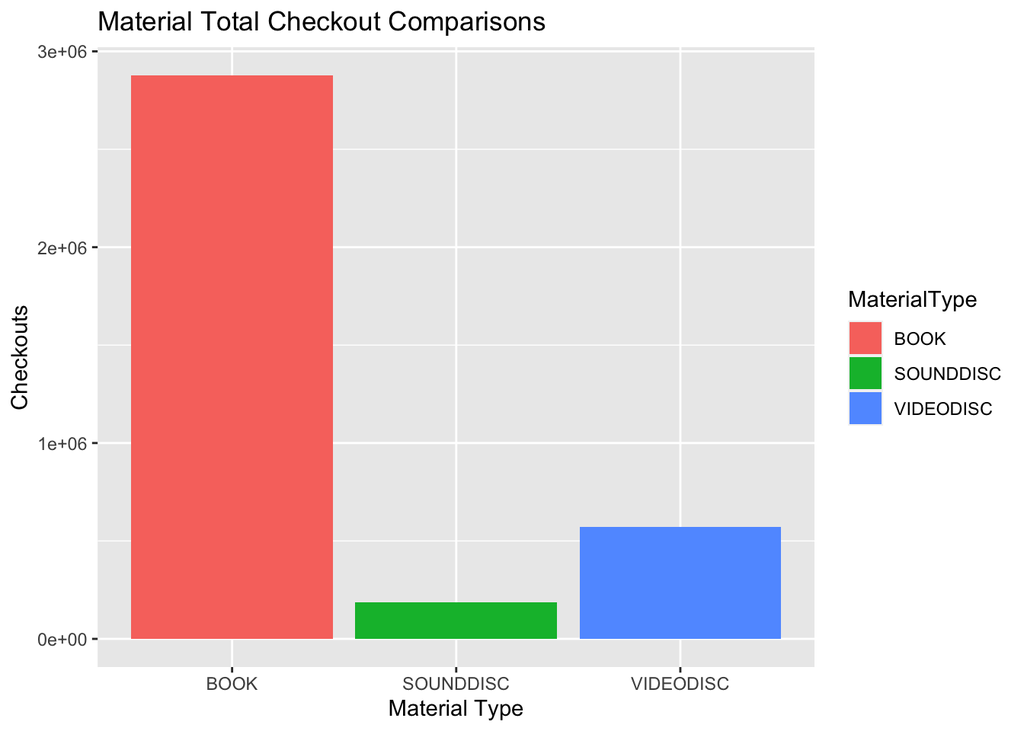

This last chart shows the top 3 material types checked out from the library. I chose this chart to give context to my previous charts, and why I chose to analyze book and video disc trends. As can be seen by the chart, books and video discs are the two most popular material types checked out from the library.